# Pertemuan 4

Megawati Roito Panjaitan (G1401211106)

2023-09-21

## White Noise

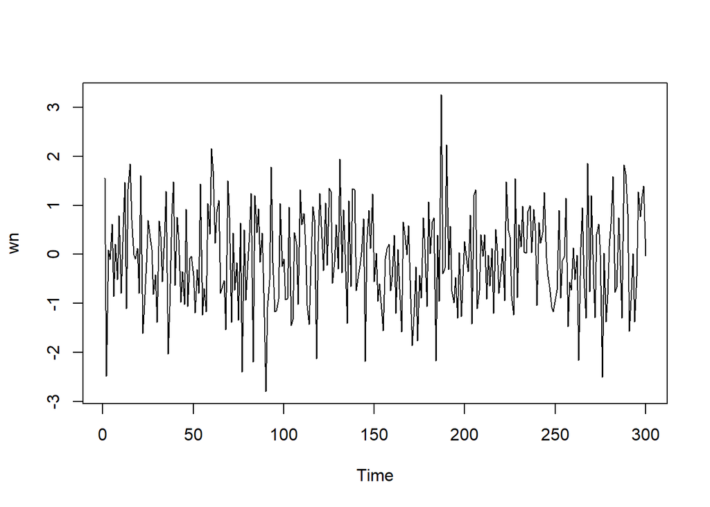

```r
wn <- rnorm(300)
ts.plot(wn)
```

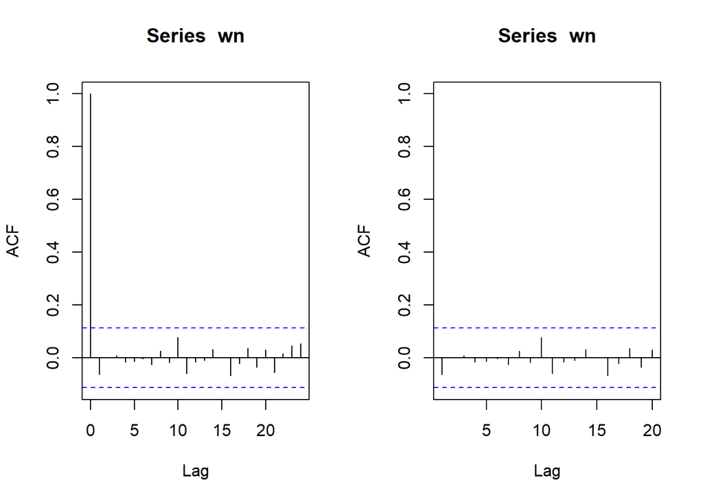

```r
par(mfrow = c(1, 2))
acf(wn)
acf(wn, xlim = c(1, 20))
```

## 1. Proses MA

### Pembangkitan proses MA(2)

```r
set.seed(106)
ma <- wn[1]
ma[2]<-wn[2] + 0.4 * wn[1]
```

Nilai-nilai selanjutnya dapat dicari melalui *loop*. Bentuk loop dapat dilihat dari rumus MA(2) yang hendak dibangkitkan:

$$y_t = e_t+0.4e_{t-1}+0.6e_{t-2}$$
#### Manual

```r
for(i in 3:300){
   ma[i] <- wn[i] + 0.4 * wn[i - 1] + 0.6 * wn[i - 2]
}
ma
```

```
##   [1]  1.5531629402 -1.8644141699  0.0252316534 -1.5634993027  0.6249847479
##   [6] -0.6798534666  0.2367970698 -0.9452336402  0.7166582752 -0.7804054815
##  [11]  0.4141855608  1.0960973033 -0.3626304310  1.7659304228  1.7113898101
##  [16]  2.2367545240  1.3838328108  0.3332673928  0.0899089203 -0.7902056989
##  [21]  1.3706002348 -1.4392881274 -0.7230315901 -1.5554340778 -0.0050247445
##  [26]  0.5140754274  0.6487805500 -0.5748629414 -0.6818683197 -2.0446692769
##  [31] -0.1159469771 -0.1908828596  0.0054848839  0.3637002225  1.0995953971
##  [36] -1.3009060306 -1.1007498384 -0.8237684263  1.1736290190  0.4504615339
##  [41]  1.3932253406  0.2286970762 -0.4041537231 -0.5577271424 -1.7481286206
##  [46]  0.2983524944 -1.3121335220  0.0437241883 -0.7139242534 -0.4954632990
##  [51] -1.3902820895 -1.0453620219 -1.6322274069  0.9357197015 -1.1327820572
##  [56] -0.3307837363 -2.1927186044  0.1495535721  0.1292297764  2.9520100007
##  [61]  2.8204521773  2.2064214696  1.9798990872  1.5886300425  0.1684629274
##  [66] -0.2967869004 -1.2674714645 -2.1373985135  0.5666588281  0.4422620732
##  [71] -0.1782167198  0.3414383608 -1.3829337474 -0.1944142890 -1.8424531151
```

[output cut: 45 more lines]

#### arima.sim

```r
ma2 <- arima.sim(list(order=c(0,0,2), ma=c(0.4,0.6)), n=300)
ma2
```

```
## Time Series:
## Start = 1
## End = 300
## Frequency = 1
##   [1] -0.77986344  0.31514519  0.09175785  1.04291346 -0.55740727  1.45412462
##   [7]  2.18537295  2.00476222 -0.73419047 -0.16586056 -0.05852052 -0.53867934
##  [13] -0.05577752 -1.76313863  0.17311020 -0.56838741 -0.19474988  0.13012968
##  [19]  0.61066716  0.67995454  0.37601259 -0.46909878 -1.50472951  0.35266159
##  [25]  0.50888617  0.72673989 -0.16821909 -0.34722200 -2.07029087 -1.10792573
##  [31] -0.88750859 -0.10263261 -0.35427490 -0.71694465 -1.07454602  0.29032924
##  [37] -0.82221056 -0.85291063 -1.30180941 -1.56653439 -0.12590008  0.68394468
##  [43]  0.67333833 -0.13580138  0.25463886  0.73272485  0.87836592  1.16360123
##  [49] -1.36043967  1.01709289 -0.30781720  1.66327521 -0.52110202  0.26242465
##  [55] -0.86269076  1.89206293  1.33242005  2.64288544  2.31798595  1.04170530
##  [61] -0.91134458 -1.45736777 -1.94723793 -0.29744050  1.19062187  0.89017980
```

[output cut: 39 more lines]

### Karakteristik MA(2)

#### Plot time series

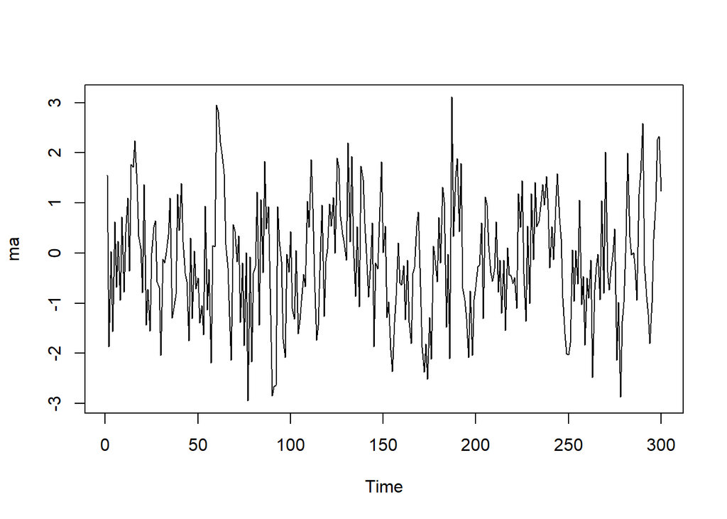

```r
ts.plot(ma)
```

Berdasarkan plot time series, terlihat bahwa data MA[2] yang dibangkitkan menyebar stasioner dalam rataan.

#### Plot ACF dan PACF

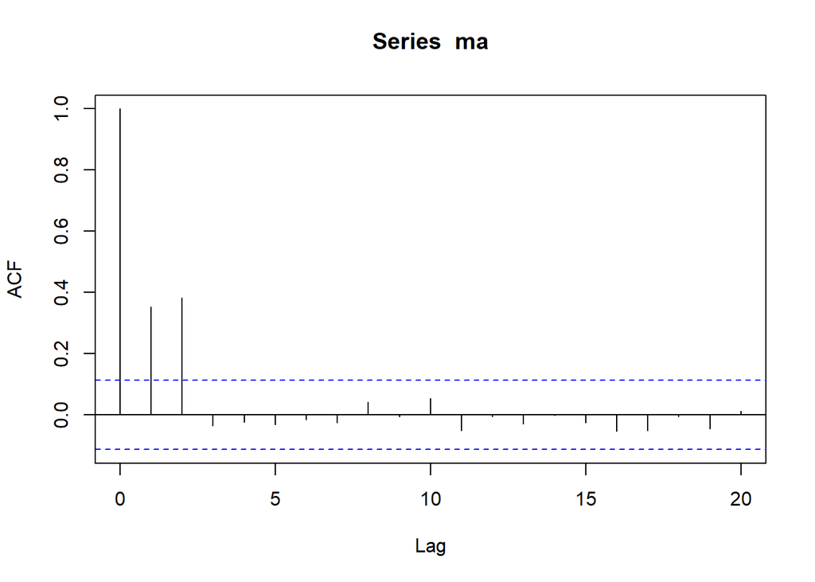

```r
acf(ma,lag.max = 20)
```

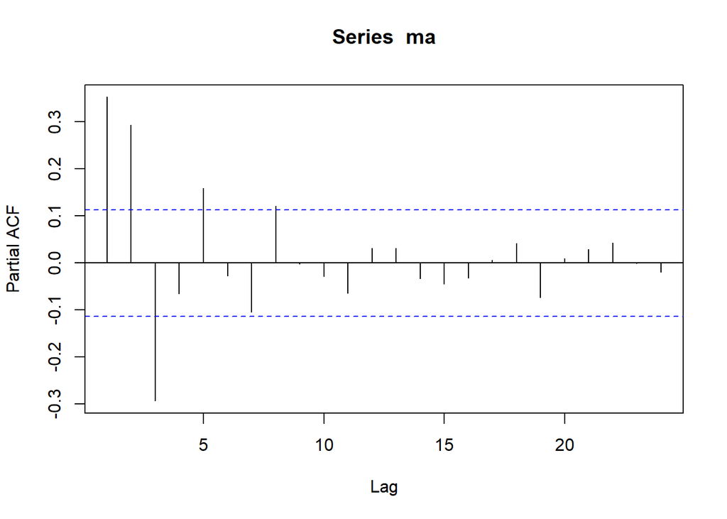

```r
pacf(ma)
```

Berdasarkan plot ACF tersebut, terlihat bahwa terdapat *cuts-off* di lag pertama dan kedua Berdasarkan plot PACF tersebut, terlihat bahwa terdapat *cuts-off* dan *tails off*

#### Plot EACF

```r
library(TSA)
```

```r
eacf(ma)
```

```
## AR/MA
##   0 1 2 3 4 5 6 7 8 9 10 11 12 13
## 0 x x o o o o o o o o o  o  o  o
## 1 x x x o o o o o o o o  o  o  o
## 2 x x x x o o o o o o o  o  o  o
## 3 x x x x o o o o o o o  o  o  o
## 4 x x x o o o o o o o o  o  o  o
## 5 x x o o x o o o o o o  o  o  o
## 6 x x x o x o o x o o o  o  o  o
## 7 x x x x x o o o o o o  o  o  o
```

Berdasarkan pola segitiga nol pada plot EACF tersebut terlihat bahwa segitiga nol berada pada ordo AR(0) dan MA(2).

#### Scatterplot antar lag

##### $Y_t$ dengan $Y_{t-1}$

```r
#Yt
yt_ma<- ma[-1]
yt_ma
```

```
##   [1] -1.8644141699  0.0252316534 -1.5634993027  0.6249847479 -0.6798534666
##   [6]  0.2367970698 -0.9452336402  0.7166582752 -0.7804054815  0.4141855608
##  [11]  1.0960973033 -0.3626304310  1.7659304228  1.7113898101  2.2367545240
##  [16]  1.3838328108  0.3332673928  0.0899089203 -0.7902056989  1.3706002348
##  [21] -1.4392881274 -0.7230315901 -1.5554340778 -0.0050247445  0.5140754274
##  [26]  0.6487805500 -0.5748629414 -0.6818683197 -2.0446692769 -0.1159469771
##  [31] -0.1908828596  0.0054848839  0.3637002225  1.0995953971 -1.3009060306
##  [36] -1.1007498384 -0.8237684263  1.1736290190  0.4504615339  1.3932253406
##  [41]  0.2286970762 -0.4041537231 -0.5577271424 -1.7481286206  0.2983524944
##  [46] -1.3121335220  0.0437241883 -0.7139242534 -0.4954632990 -1.3902820895
##  [51] -1.0453620219 -1.6322274069  0.9357197015 -1.1327820572 -0.3307837363
##  [56] -2.1927186044  0.1495535721  0.1292297764  2.9520100007  2.8204521773
##  [61]  2.2064214696  1.9798990872  1.5886300425  0.1684629274 -0.2967869004
##  [66] -1.2674714645 -2.1373985135  0.5666588281  0.4422620732 -0.1782167198
##  [71]  0.3414383608 -1.3829337474 -0.1944142890 -1.8424531151  0.0036575633
```

[output cut: 45 more lines]

```r
#Yt-1
yt_1_ma <- ma[-300]
yt_1_ma
```

```
##   [1]  1.5531629402 -1.8644141699  0.0252316534 -1.5634993027  0.6249847479
##   [6] -0.6798534666  0.2367970698 -0.9452336402  0.7166582752 -0.7804054815
##  [11]  0.4141855608  1.0960973033 -0.3626304310  1.7659304228  1.7113898101
##  [16]  2.2367545240  1.3838328108  0.3332673928  0.0899089203 -0.7902056989
##  [21]  1.3706002348 -1.4392881274 -0.7230315901 -1.5554340778 -0.0050247445
##  [26]  0.5140754274  0.6487805500 -0.5748629414 -0.6818683197 -2.0446692769
##  [31] -0.1159469771 -0.1908828596  0.0054848839  0.3637002225  1.0995953971
##  [36] -1.3009060306 -1.1007498384 -0.8237684263  1.1736290190  0.4504615339
##  [41]  1.3932253406  0.2286970762 -0.4041537231 -0.5577271424 -1.7481286206
##  [46]  0.2983524944 -1.3121335220  0.0437241883 -0.7139242534 -0.4954632990
##  [51] -1.3902820895 -1.0453620219 -1.6322274069  0.9357197015 -1.1327820572
##  [56] -0.3307837363 -2.1927186044  0.1495535721  0.1292297764  2.9520100007
##  [61]  2.8204521773  2.2064214696  1.9798990872  1.5886300425  0.1684629274
##  [66] -0.2967869004 -1.2674714645 -2.1373985135  0.5666588281  0.4422620732
##  [71] -0.1782167198  0.3414383608 -1.3829337474 -0.1944142890 -1.8424531151
```

[output cut: 45 more lines]

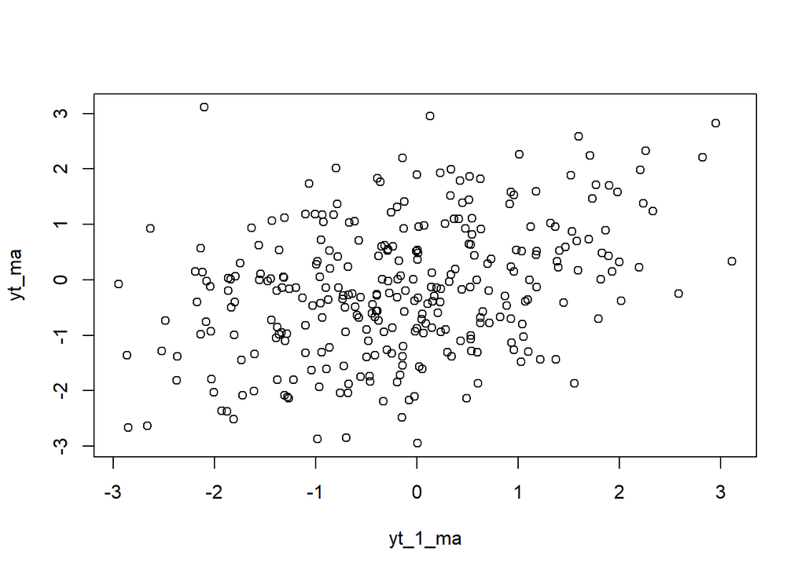

```r
plot(y=yt_ma,x=yt_1_ma)
```

Berdasarkan scatterplot tersebut, terlihat bahwa terdapat hubungan positif antara $Y_t$ dengan $Y_{t-1}$. Hal ini sesuai dengan teori yang ada.

```r
# Korelasi antara yt dan y_(t-1)
cor(yt_ma,yt_1_ma)
```

```
## [1] 0.3549528
```

#### $Y_t$ dengan $Y_{t-2}$

```r
#Yt
yt_ma2 <- ma[-c(1,2)]
yt_ma2
```

```
##   [1]  0.0252316534 -1.5634993027  0.6249847479 -0.6798534666  0.2367970698
##   [6] -0.9452336402  0.7166582752 -0.7804054815  0.4141855608  1.0960973033
##  [11] -0.3626304310  1.7659304228  1.7113898101  2.2367545240  1.3838328108
##  [16]  0.3332673928  0.0899089203 -0.7902056989  1.3706002348 -1.4392881274
##  [21] -0.7230315901 -1.5554340778 -0.0050247445  0.5140754274  0.6487805500
##  [26] -0.5748629414 -0.6818683197 -2.0446692769 -0.1159469771 -0.1908828596
##  [31]  0.0054848839  0.3637002225  1.0995953971 -1.3009060306 -1.1007498384
##  [36] -0.8237684263  1.1736290190  0.4504615339  1.3932253406  0.2286970762
##  [41] -0.4041537231 -0.5577271424 -1.7481286206  0.2983524944 -1.3121335220
##  [46]  0.0437241883 -0.7139242534 -0.4954632990 -1.3902820895 -1.0453620219
##  [51] -1.6322274069  0.9357197015 -1.1327820572 -0.3307837363 -2.1927186044
##  [56]  0.1495535721  0.1292297764  2.9520100007  2.8204521773  2.2064214696
##  [61]  1.9798990872  1.5886300425  0.1684629274 -0.2967869004 -1.2674714645
##  [66] -2.1373985135  0.5666588281  0.4422620732 -0.1782167198  0.3414383608
##  [71] -1.3829337474 -0.1944142890 -1.8424531151  0.0036575633 -2.9484054857
```

[output cut: 45 more lines]

```r
#Yt-2
yt_2_ma <- ma[-c(299,300)]
yt_2_ma
```

```
##   [1]  1.5531629402 -1.8644141699  0.0252316534 -1.5634993027  0.6249847479
##   [6] -0.6798534666  0.2367970698 -0.9452336402  0.7166582752 -0.7804054815
##  [11]  0.4141855608  1.0960973033 -0.3626304310  1.7659304228  1.7113898101
##  [16]  2.2367545240  1.3838328108  0.3332673928  0.0899089203 -0.7902056989
##  [21]  1.3706002348 -1.4392881274 -0.7230315901 -1.5554340778 -0.0050247445
##  [26]  0.5140754274  0.6487805500 -0.5748629414 -0.6818683197 -2.0446692769
##  [31] -0.1159469771 -0.1908828596  0.0054848839  0.3637002225  1.0995953971
##  [36] -1.3009060306 -1.1007498384 -0.8237684263  1.1736290190  0.4504615339
##  [41]  1.3932253406  0.2286970762 -0.4041537231 -0.5577271424 -1.7481286206
##  [46]  0.2983524944 -1.3121335220  0.0437241883 -0.7139242534 -0.4954632990
##  [51] -1.3902820895 -1.0453620219 -1.6322274069  0.9357197015 -1.1327820572
##  [56] -0.3307837363 -2.1927186044  0.1495535721  0.1292297764  2.9520100007
##  [61]  2.8204521773  2.2064214696  1.9798990872  1.5886300425  0.1684629274
##  [66] -0.2967869004 -1.2674714645 -2.1373985135  0.5666588281  0.4422620732
##  [71] -0.1782167198  0.3414383608 -1.3829337474 -0.1944142890 -1.8424531151
```

[output cut: 45 more lines]

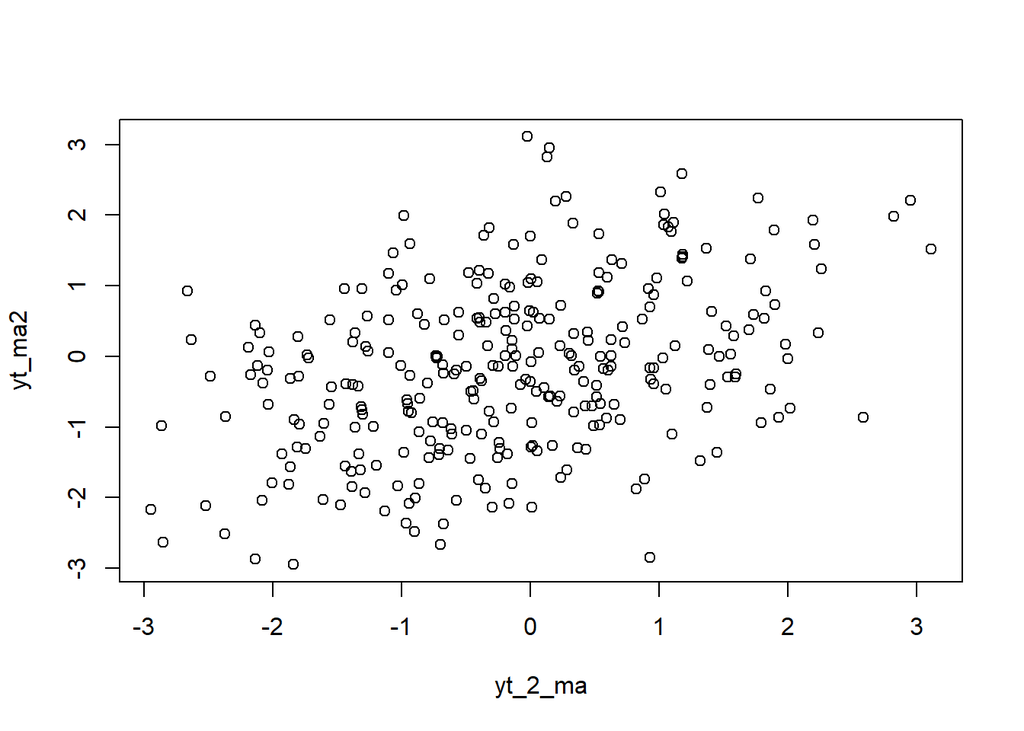

```r
plot(y=yt_ma2,x=yt_2_ma)
```

Berdasarkan scatterplot tersebut, terlihat bahwa terdapat hubungan positif antara $Y_t$ dengan $Y_{t-2}$. Hal ini sesuai dengan teori yang ada.

```r
cor(yt_ma2,yt_2_ma)
```

```
## [1] 0.3882511
```

### $Y_t$ dengan $Y_{t-3}$

```r
#Yt
yt_ma3 <- ma[-c(1,2,3)]
yt_ma3
```

```
##   [1] -1.5634993027  0.6249847479 -0.6798534666  0.2367970698 -0.9452336402
##   [6]  0.7166582752 -0.7804054815  0.4141855608  1.0960973033 -0.3626304310
##  [11]  1.7659304228  1.7113898101  2.2367545240  1.3838328108  0.3332673928
##  [16]  0.0899089203 -0.7902056989  1.3706002348 -1.4392881274 -0.7230315901
##  [21] -1.5554340778 -0.0050247445  0.5140754274  0.6487805500 -0.5748629414
##  [26] -0.6818683197 -2.0446692769 -0.1159469771 -0.1908828596  0.0054848839
##  [31]  0.3637002225  1.0995953971 -1.3009060306 -1.1007498384 -0.8237684263
##  [36]  1.1736290190  0.4504615339  1.3932253406  0.2286970762 -0.4041537231
##  [41] -0.5577271424 -1.7481286206  0.2983524944 -1.3121335220  0.0437241883
##  [46] -0.7139242534 -0.4954632990 -1.3902820895 -1.0453620219 -1.6322274069
##  [51]  0.9357197015 -1.1327820572 -0.3307837363 -2.1927186044  0.1495535721
##  [56]  0.1292297764  2.9520100007  2.8204521773  2.2064214696  1.9798990872
##  [61]  1.5886300425  0.1684629274 -0.2967869004 -1.2674714645 -2.1373985135
##  [66]  0.5666588281  0.4422620732 -0.1782167198  0.3414383608 -1.3829337474
##  [71] -0.1944142890 -1.8424531151  0.0036575633 -2.9484054857 -0.0775752632
```

[output cut: 45 more lines]

```r
#Yt-3
yt_3_ma <- ma[-c(298,299,300)]
yt_3_ma
```

```
##   [1]  1.5531629402 -1.8644141699  0.0252316534 -1.5634993027  0.6249847479
##   [6] -0.6798534666  0.2367970698 -0.9452336402  0.7166582752 -0.7804054815
##  [11]  0.4141855608  1.0960973033 -0.3626304310  1.7659304228  1.7113898101
##  [16]  2.2367545240  1.3838328108  0.3332673928  0.0899089203 -0.7902056989
##  [21]  1.3706002348 -1.4392881274 -0.7230315901 -1.5554340778 -0.0050247445
##  [26]  0.5140754274  0.6487805500 -0.5748629414 -0.6818683197 -2.0446692769
##  [31] -0.1159469771 -0.1908828596  0.0054848839  0.3637002225  1.0995953971
##  [36] -1.3009060306 -1.1007498384 -0.8237684263  1.1736290190  0.4504615339
##  [41]  1.3932253406  0.2286970762 -0.4041537231 -0.5577271424 -1.7481286206
##  [46]  0.2983524944 -1.3121335220  0.0437241883 -0.7139242534 -0.4954632990
##  [51] -1.3902820895 -1.0453620219 -1.6322274069  0.9357197015 -1.1327820572
##  [56] -0.3307837363 -2.1927186044  0.1495535721  0.1292297764  2.9520100007
##  [61]  2.8204521773  2.2064214696  1.9798990872  1.5886300425  0.1684629274
##  [66] -0.2967869004 -1.2674714645 -2.1373985135  0.5666588281  0.4422620732
##  [71] -0.1782167198  0.3414383608 -1.3829337474 -0.1944142890 -1.8424531151
```

[output cut: 45 more lines]

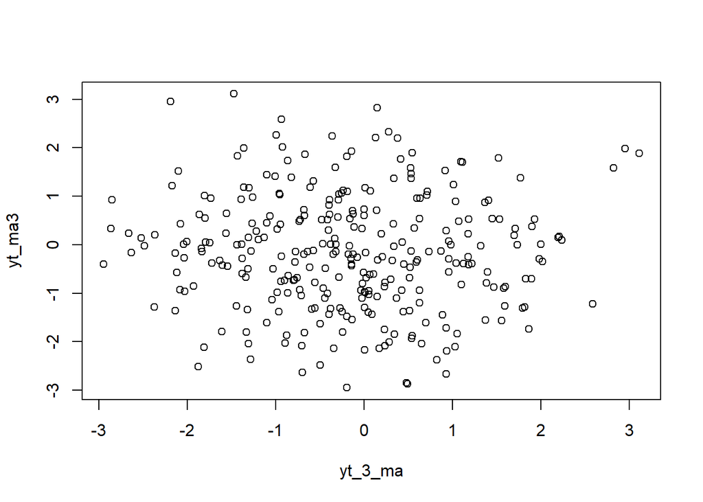

```r
plot(y=yt_ma3,x=yt_3_ma)
```

Berdasarkan scatterplot tersebut, terlihat bahwa cenderung tidak terdapat hubungan antara $Y_t$ dengan $Y_{t-3}$.

```r
cor(yt_ma3,yt_3_ma)
```

```
## [1] -0.03614464
```

Korelasi antara $Y_t$ dengan $Y_{t-3}$ hasil simulasi mendekati teori yang ada yaitu 0.

## 2. Proses AR

### Pembangkitan proses AR(2)

```r
set.seed(106)
```

```r
n<-length(wn)
n
```

```
## [1] 300
```

```r
ar <- c(1:n)
for (i in 3:n) {ar[i]<-wn[i]+0.5*ar[i-1]+0.2*ar[i-2]}
ar
```

```
##   [1]  1.000000000  2.000000000  1.287605628  0.936668868  1.341130509
##   [6] -0.003784051  0.478639408 -0.274583032  0.752969812 -0.468763005
##  [11]  0.169810475  1.460009517 -0.338365139  1.448368425  2.499080554
##  [16]  2.243611284  1.618154013  1.169815359  1.035721608 -0.036464731
##  [21]  1.798517758 -0.718191351 -1.044124282 -0.837147255  0.062994804
##  [26]  0.204854170  0.213256135 -0.671027807 -0.706218367 -1.875465720
##  [31] -0.391649706 -0.203841002 -0.733992453 -0.042813597  1.117654982
##  [36] -1.483955865 -1.577024683 -0.265108460  1.032738479 -0.170587009
##  [41]  0.879634767  0.711405561 -0.449834567 -0.431200941 -1.325391516
##  [46]  0.166485063 -1.248243218 -0.669790035 -0.627037271 -0.878563234
##  [51] -1.757040358 -1.364002378 -1.826318075  0.252785445 -1.471405644
##  [56] -1.386162544 -2.160153430 -0.318029153 -0.173852897  2.011032733
##  [61]  2.676256540  1.967612978  2.384739168  2.691882777  1.029547088
##  [66]  0.410105694 -0.123286157 -1.517494441  0.718952430  0.820020148
##  [71] -0.831447418  0.185392180 -0.800223098 -0.529062636 -1.764639421
```

[output cut: 45 more lines]

#### arima.sim

```r
ar2 <- arima.sim(list(order=c(2,0,0), ar=c(0.5,0.2)), n=300)
ar2
```

```
## Time Series:
## Start = 1
## End = 300
## Frequency = 1
##   [1]  0.410769308  0.733024609  0.165170531 -0.305236671 -0.082938101
##   [6] -1.866809591 -1.374188538 -0.719710400 -0.619106155 -1.018452232
##  [11] -1.133361223 -1.305817282 -0.074884828 -1.121427123 -1.582290294
##  [16] -1.420907325 -1.827295552 -0.760289733  0.243555198 -0.015129391
##  [21] -0.694210928  0.189559853  0.914000474  0.666238321  1.036152404
##  [26] -1.020004730  1.070712556  0.476941509  1.233563340 -0.208663786
##  [31]  0.304568880 -0.264514070  1.873433114  1.663362695  2.370568006
##  [36]  2.902533110  1.714734811 -0.219958360 -0.434879824 -0.946831036
##  [41] -0.182963637  1.170042378  0.631795389  0.324106306  0.508728577
##  [46]  0.706462201 -1.069057676  0.275868413  2.122011221  1.648728975
##  [51]  1.504567846  1.612716165 -0.896859527 -0.230756443  0.247213150
```

[output cut: 49 more lines]

### Karakteristik AR(2)

#### Plot Time Series

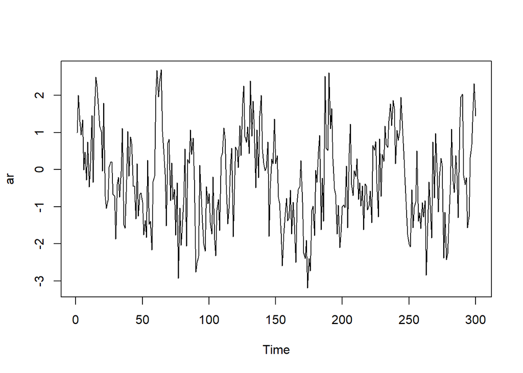

```r
ts.plot(ar)
```

Berdasarkan plot time series tersebut terlihat bahwa data cenderung stasioner pada rataan

#### Plot ACF dan PACF

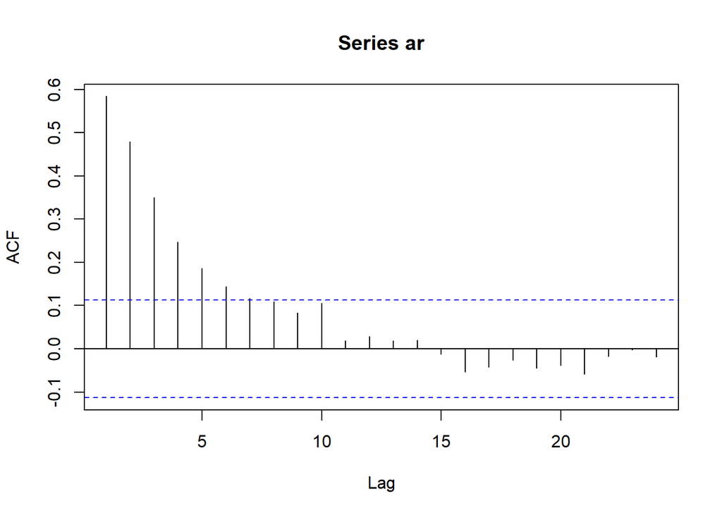

```r
acf(ar)
```

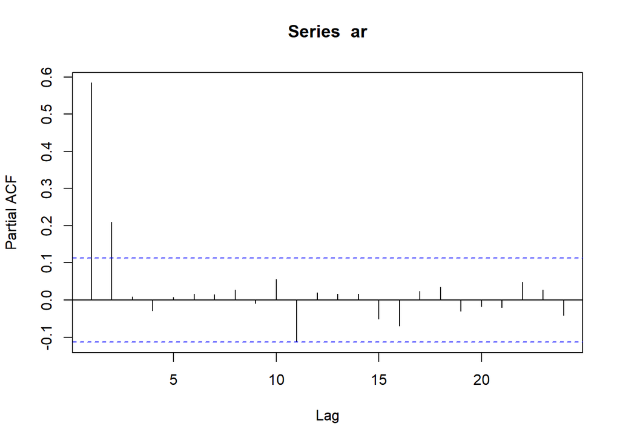

```r
pacf(ar)
```

#### Plot EACF

```r
library(TSA)
eacf(ar)
```

```
## AR/MA
##   0 1 2 3 4 5 6 7 8 9 10 11 12 13
## 0 x x x x x x x o o o o  o  o  o
## 1 x o o o o o o o o o o  o  o  o
## 2 o x o o o o o o o o o  o  o  o
## 3 x o o o o o o o o o o  o  o  o
## 4 x x o o o o o o o o o  o  o  o
## 5 x o o o o o o o o o o  o  o  o
## 6 x o o x o o o o o o o  o  o  o
## 7 x x o o o o o o o o o  o  o  o
```

#### Scatterplot antar lag

##### $Y_t$ dengan $Y_{t-1}$

```r
#Yt
yt_ar<- ar[-1]
yt_ar
```

```
##   [1]  2.000000000  1.287605628  0.936668868  1.341130509 -0.003784051
##   [6]  0.478639408 -0.274583032  0.752969812 -0.468763005  0.169810475
##  [11]  1.460009517 -0.338365139  1.448368425  2.499080554  2.243611284
##  [16]  1.618154013  1.169815359  1.035721608 -0.036464731  1.798517758
##  [21] -0.718191351 -1.044124282 -0.837147255  0.062994804  0.204854170
##  [26]  0.213256135 -0.671027807 -0.706218367 -1.875465720 -0.391649706
##  [31] -0.203841002 -0.733992453 -0.042813597  1.117654982 -1.483955865
##  [36] -1.577024683 -0.265108460  1.032738479 -0.170587009  0.879634767
##  [41]  0.711405561 -0.449834567 -0.431200941 -1.325391516  0.166485063
##  [46] -1.248243218 -0.669790035 -0.627037271 -0.878563234 -1.757040358
##  [51] -1.364002378 -1.826318075  0.252785445 -1.471405644 -1.386162544
##  [56] -2.160153430 -0.318029153 -0.173852897  2.011032733  2.676256540
##  [61]  1.967612978  2.384739168  2.691882777  1.029547088  0.410105694
##  [66] -0.123286157 -1.517494441  0.718952430  0.820020148 -0.831447418
##  [71]  0.185392180 -0.800223098 -0.529062636 -1.764639421 -0.348831567
```

[output cut: 45 more lines]

```r
#Yt-1
yt_1_ar <- ar[-300]
yt_1_ar
```

```
##   [1]  1.000000000  2.000000000  1.287605628  0.936668868  1.341130509
##   [6] -0.003784051  0.478639408 -0.274583032  0.752969812 -0.468763005
##  [11]  0.169810475  1.460009517 -0.338365139  1.448368425  2.499080554
##  [16]  2.243611284  1.618154013  1.169815359  1.035721608 -0.036464731
##  [21]  1.798517758 -0.718191351 -1.044124282 -0.837147255  0.062994804
##  [26]  0.204854170  0.213256135 -0.671027807 -0.706218367 -1.875465720
##  [31] -0.391649706 -0.203841002 -0.733992453 -0.042813597  1.117654982
##  [36] -1.483955865 -1.577024683 -0.265108460  1.032738479 -0.170587009
##  [41]  0.879634767  0.711405561 -0.449834567 -0.431200941 -1.325391516
##  [46]  0.166485063 -1.248243218 -0.669790035 -0.627037271 -0.878563234
##  [51] -1.757040358 -1.364002378 -1.826318075  0.252785445 -1.471405644
##  [56] -1.386162544 -2.160153430 -0.318029153 -0.173852897  2.011032733
##  [61]  2.676256540  1.967612978  2.384739168  2.691882777  1.029547088
##  [66]  0.410105694 -0.123286157 -1.517494441  0.718952430  0.820020148
##  [71] -0.831447418  0.185392180 -0.800223098 -0.529062636 -1.764639421
```

[output cut: 45 more lines]

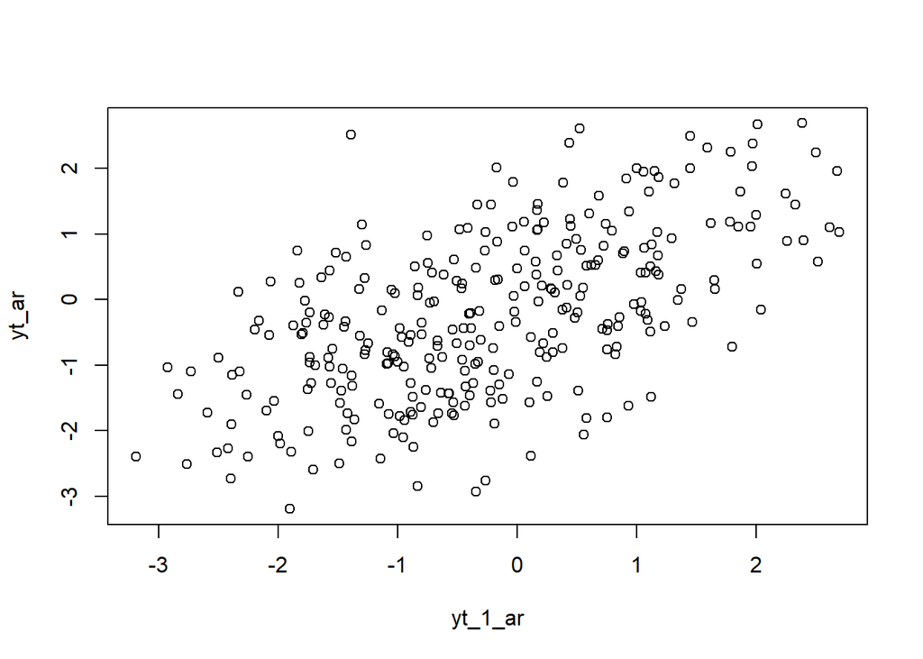

```r
plot(y=yt_ar,x=yt_1_ar)
```

Berdasarkan scatterplot tersebut, terlihat bahwa terdapat hubungan positif antara $Y_t$ dengan $Y_{t-1}$. Hal ini sesuai dengan teori yang ada

```r
cor(yt_ar,yt_1_ar)
```

```
## [1] 0.5869832
```

##### $Y_t$ dengan $Y_{t-2}$

```r
#Yt
yt_ar2 <- ar[-c(1,2)]
yt_ar2
```

```
##   [1]  1.287605628  0.936668868  1.341130509 -0.003784051  0.478639408
##   [6] -0.274583032  0.752969812 -0.468763005  0.169810475  1.460009517
##  [11] -0.338365139  1.448368425  2.499080554  2.243611284  1.618154013
##  [16]  1.169815359  1.035721608 -0.036464731  1.798517758 -0.718191351
##  [21] -1.044124282 -0.837147255  0.062994804  0.204854170  0.213256135
##  [26] -0.671027807 -0.706218367 -1.875465720 -0.391649706 -0.203841002
##  [31] -0.733992453 -0.042813597  1.117654982 -1.483955865 -1.577024683
##  [36] -0.265108460  1.032738479 -0.170587009  0.879634767  0.711405561
##  [41] -0.449834567 -0.431200941 -1.325391516  0.166485063 -1.248243218
##  [46] -0.669790035 -0.627037271 -0.878563234 -1.757040358 -1.364002378
##  [51] -1.826318075  0.252785445 -1.471405644 -1.386162544 -2.160153430
##  [56] -0.318029153 -0.173852897  2.011032733  2.676256540  1.967612978
##  [61]  2.384739168  2.691882777  1.029547088  0.410105694 -0.123286157
##  [66] -1.517494441  0.718952430  0.820020148 -0.831447418  0.185392180
##  [71] -0.800223098 -0.529062636 -1.764639421 -0.348831567 -2.927431332
```

[output cut: 45 more lines]

```r
#Yt-2
yt_2_ar <- ar[-c(299,300)]
yt_2_ar
```

```
##   [1]  1.000000000  2.000000000  1.287605628  0.936668868  1.341130509
##   [6] -0.003784051  0.478639408 -0.274583032  0.752969812 -0.468763005
##  [11]  0.169810475  1.460009517 -0.338365139  1.448368425  2.499080554
##  [16]  2.243611284  1.618154013  1.169815359  1.035721608 -0.036464731
##  [21]  1.798517758 -0.718191351 -1.044124282 -0.837147255  0.062994804
##  [26]  0.204854170  0.213256135 -0.671027807 -0.706218367 -1.875465720
##  [31] -0.391649706 -0.203841002 -0.733992453 -0.042813597  1.117654982
##  [36] -1.483955865 -1.577024683 -0.265108460  1.032738479 -0.170587009
##  [41]  0.879634767  0.711405561 -0.449834567 -0.431200941 -1.325391516
##  [46]  0.166485063 -1.248243218 -0.669790035 -0.627037271 -0.878563234
##  [51] -1.757040358 -1.364002378 -1.826318075  0.252785445 -1.471405644
##  [56] -1.386162544 -2.160153430 -0.318029153 -0.173852897  2.011032733
##  [61]  2.676256540  1.967612978  2.384739168  2.691882777  1.029547088
##  [66]  0.410105694 -0.123286157 -1.517494441  0.718952430  0.820020148
##  [71] -0.831447418  0.185392180 -0.800223098 -0.529062636 -1.764639421
```

[output cut: 45 more lines]

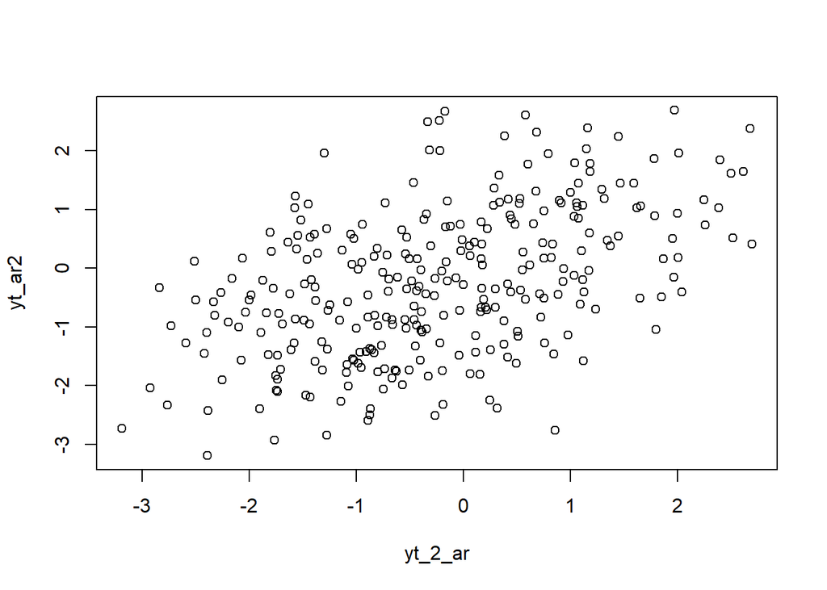

```r
plot(y=yt_ar2,x=yt_2_ar)
```

Berdasarkan scatterplot tersebut, terlihat bahwa terdapat hubungan positif antara $Y_t$ dengan $Y_{t-2}$. Hal ini sesuai dengan teori yang ada

```r
cor(yt_ar2,yt_2_ar)
```

```
## [1] 0.4880452
```

##### $Y_t$ dengan $Y_{t-3}$

```r
#Yt
yt_ar3 <- ar[-c(1,2,3)]
yt_ar3
```

```
##   [1]  0.936668868  1.341130509 -0.003784051  0.478639408 -0.274583032
##   [6]  0.752969812 -0.468763005  0.169810475  1.460009517 -0.338365139
##  [11]  1.448368425  2.499080554  2.243611284  1.618154013  1.169815359
##  [16]  1.035721608 -0.036464731  1.798517758 -0.718191351 -1.044124282
##  [21] -0.837147255  0.062994804  0.204854170  0.213256135 -0.671027807
##  [26] -0.706218367 -1.875465720 -0.391649706 -0.203841002 -0.733992453
##  [31] -0.042813597  1.117654982 -1.483955865 -1.577024683 -0.265108460
##  [36]  1.032738479 -0.170587009  0.879634767  0.711405561 -0.449834567
##  [41] -0.431200941 -1.325391516  0.166485063 -1.248243218 -0.669790035
##  [46] -0.627037271 -0.878563234 -1.757040358 -1.364002378 -1.826318075
##  [51]  0.252785445 -1.471405644 -1.386162544 -2.160153430 -0.318029153
##  [56] -0.173852897  2.011032733  2.676256540  1.967612978  2.384739168
##  [61]  2.691882777  1.029547088  0.410105694 -0.123286157 -1.517494441
##  [66]  0.718952430  0.820020148 -0.831447418  0.185392180 -0.800223098
##  [71] -0.529062636 -1.764639421 -0.348831567 -2.927431332 -1.034602579
```

[output cut: 45 more lines]

```r
#Yt-3
yt_3_ar <- ar[-c(298,299,300)]
yt_3_ar
```

```
##   [1]  1.000000000  2.000000000  1.287605628  0.936668868  1.341130509
##   [6] -0.003784051  0.478639408 -0.274583032  0.752969812 -0.468763005
##  [11]  0.169810475  1.460009517 -0.338365139  1.448368425  2.499080554
##  [16]  2.243611284  1.618154013  1.169815359  1.035721608 -0.036464731
##  [21]  1.798517758 -0.718191351 -1.044124282 -0.837147255  0.062994804
##  [26]  0.204854170  0.213256135 -0.671027807 -0.706218367 -1.875465720
##  [31] -0.391649706 -0.203841002 -0.733992453 -0.042813597  1.117654982
##  [36] -1.483955865 -1.577024683 -0.265108460  1.032738479 -0.170587009
##  [41]  0.879634767  0.711405561 -0.449834567 -0.431200941 -1.325391516
##  [46]  0.166485063 -1.248243218 -0.669790035 -0.627037271 -0.878563234
##  [51] -1.757040358 -1.364002378 -1.826318075  0.252785445 -1.471405644
##  [56] -1.386162544 -2.160153430 -0.318029153 -0.173852897  2.011032733
##  [61]  2.676256540  1.967612978  2.384739168  2.691882777  1.029547088
##  [66]  0.410105694 -0.123286157 -1.517494441  0.718952430  0.820020148
##  [71] -0.831447418  0.185392180 -0.800223098 -0.529062636 -1.764639421
```

[output cut: 45 more lines]

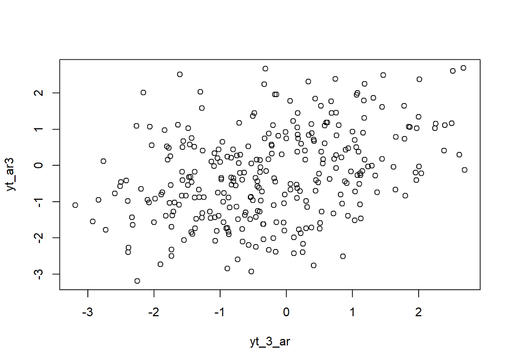

```r
plot(y=yt_ar3,x=yt_3_ar)
```

Berdasarkan scatterplot tersebut, terlihat bahwa terdapat hubungan positif antara $Y_t$ dengan $Y_{t-3}$. Hal ini sesuai dengan teori yang ada

```r
cor(yt_ar3,yt_3_ar)
```

```
## [1] 0.3579036
```

## 3. Proses ARMA(2,2)

#### Manual

```r
set.seed(100)
n = length(wn)
phi1 = 0.5
phi2 = 0.2
theta1 = 0.4
theta2 = 0.6
```

```r
y.arma=c(1:n)
for(i in 3:n)
{
y.arma[i] = phi1*y.arma[i-1] + phi2*y.arma[i-2] + theta1*wn[i-1] + theta2*wn[i-2] + wn[i]
}
y.arma
```

```
##   [1]  1.000000000  2.000000000  1.225231653 -0.550883476  0.594589341
##   [6] -0.492735491  0.109347192 -0.989107142  0.243974142 -0.856239839
##  [11]  0.034860470  0.942279571  0.115481448  2.012127061  2.740549630
##  [16]  4.009454751  3.936670112  3.103493399  2.428989642  1.044987802
##  [21]  2.378892064 -0.040844535 -0.267675445 -1.697440707 -0.907280187
##  [26] -0.279052808  0.327798109 -0.466774449 -0.849695922 -2.562872128
##  [31] -1.567322225 -1.487118398 -1.051538760 -0.459492837  0.659541226
##  [36] -1.063033985 -1.500358586 -1.786554516 -0.019719956  0.083290653
##  [41]  1.430926676  0.960818545  0.362440884 -0.184342991 -1.767811939
##  [46] -0.622422074 -1.976906947 -1.069213700 -1.643912493 -1.531262285
##  [51] -2.484695731 -2.593962344 -3.426147725 -1.296146630 -2.466084917
##  [56] -1.823055521 -3.597463348 -2.013789206 -1.597157496  1.750673411
##  [61]  3.376357384  4.244734844  4.777537986  4.826346004  3.537143527
##  [66]  2.437054064  0.658484273 -1.320745564  0.037982900  0.197104411
##  [71] -0.072067934  0.344825276 -1.224934696 -0.737916582 -2.456398345
```

[output cut: 45 more lines]

#### arima.sim

```r
arma22 <- arima.sim(list(order=c(2,0,2), ar = c(0.5,0.2), ma = c(0.4,0.6)), n=300)
arma22
```

```
## Time Series:
## Start = 1
## End = 300
## Frequency = 1
##   [1] -0.423982089 -1.829945001 -1.077217991 -1.591518838  0.857972776
##   [6]  0.621035121  1.370172149 -0.007956387 -0.294459819 -0.468639788
##  [11]  0.064197964  1.280447276  2.299820151  2.331692495  3.570483281
##  [16]  0.975108360  1.955730067 -0.166315069  1.795026529  0.716332295
##  [21]  2.684199639  1.838707447  0.386488842 -0.611271184 -3.272954173
##  [26] -2.543542963 -1.000509445 -2.414583612 -0.197220330 -2.951322140
##  [31]  0.338515524  0.850945663  1.301767007  1.052315350  0.109557613
##  [36] -0.298376756  2.261822233  2.006523340  2.343710148  2.003844475
##  [41]  1.499738568  1.544194413  1.072603220  1.215097647 -0.118218819
##  [46] -1.134909507 -0.046157902 -2.350199766 -1.007307102 -3.293379577
##  [51] -2.004973223 -1.197011866 -2.508200886 -0.821371322 -1.848235549
```

[output cut: 49 more lines]

#### Plot Time Series

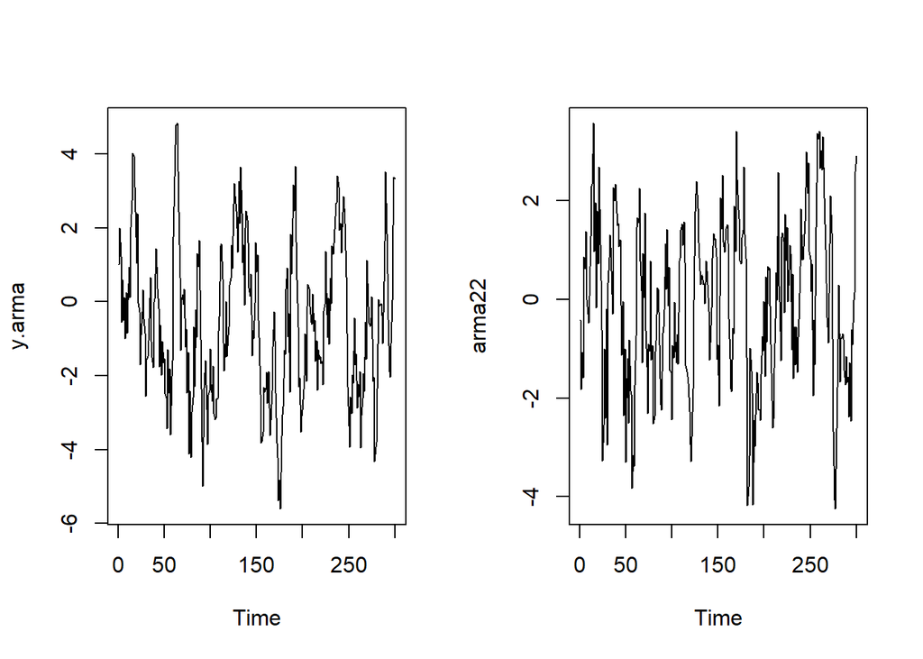

```r
par(mfrow = c(1, 2))
ts.plot(y.arma)
ts.plot(arma22)
```

```r
par(mfrow = c(1, 1))
```

Berdasarkan plot time series tersebut, terlihat bahwa model ARMA(2,2) cenderung stasioner dalam rataan

#### Plot ACF

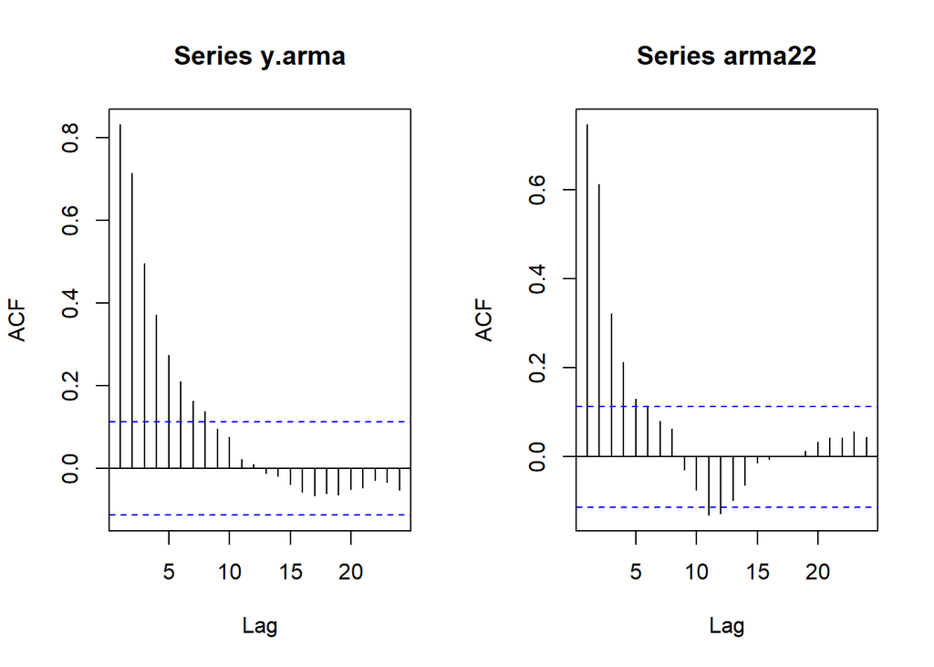

```r
par(mfrow = c(1, 2))
acf(y.arma)
acf(arma22)
```

```r
par(mfrow = c(1, 1))
```

#### Plot PACF

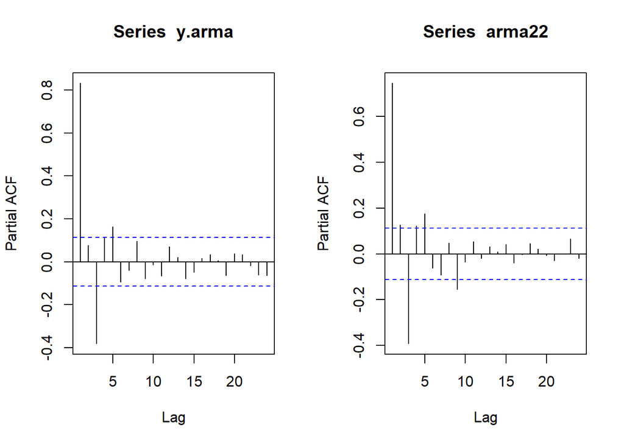

```r
par(mfrow = c(1, 2))
pacf(y.arma)
pacf(arma22)
```

```r
par(mfrow = c(1, 1))
```

Berdasarkan plot PACF tersebut, terlihat bahwa model ARMA(2,2) hasil simulasi memiliki plot PACF yang *tails off*, sesuai dengan teori

#### Plot EACF

```r
library(TSA)
eacf(arma22)
```

```
## AR/MA
##   0 1 2 3 4 5 6 7 8 9 10 11 12 13
## 0 x x x x x o o o o o x  x  o  o
## 1 x x x o x o o o o o x  o  o  o
## 2 x x o o o o o o o o o  o  o  o
## 3 x x o x o o o x o o o  o  o  o
## 4 x x x o x o o x o o o  o  o  o
## 5 x x x o x o o x o o o  o  o  o
## 6 x x o o x o x x o o o  o  o  o
## 7 x x x x x x x x x o o  o  o  o
```

#### Scatterplot antar lag

##### $Y_t$ dengan $Y_{t-1}$

```r
#Yt
yt_arma<- arma22[-1]
yt_arma
```

```
##   [1] -1.829945001 -1.077217991 -1.591518838  0.857972776  0.621035121
##   [6]  1.370172149 -0.007956387 -0.294459819 -0.468639788  0.064197964
##  [11]  1.280447276  2.299820151  2.331692495  3.570483281  0.975108360
##  [16]  1.955730067 -0.166315069  1.795026529  0.716332295  2.684199639
##  [21]  1.838707447  0.386488842 -0.611271184 -3.272954173 -2.543542963
##  [26] -1.000509445 -2.414583612 -0.197220330 -2.951322140  0.338515524
##  [31]  0.850945663  1.301767007  1.052315350  0.109557613 -0.298376756
##  [36]  2.261822233  2.006523340  2.343710148  2.003844475  1.499738568
##  [41]  1.544194413  1.072603220  1.215097647 -0.118218819 -1.134909507
##  [46] -0.046157902 -2.350199766 -1.007307102 -3.293379577 -2.004973223
##  [51] -1.197011866 -2.508200886 -0.821371322 -1.848235549 -1.915646293
##  [56] -3.826818975 -3.166651363 -3.381488796 -1.745119860 -0.739691484
##  [61]  1.465071595  1.662114755  1.561746742  2.256486660  0.784682474
##  [66]  0.185865226 -1.279230285  0.936579335  0.040043042  1.755268572
##  [71] -0.627129785 -1.359907284 -2.315126738 -0.904021314 -1.038691872
```

[output cut: 45 more lines]

```r
#Yt-1
yt_1_arma <- arma22[-300]
yt_1_arma
```

```
##   [1] -0.423982089 -1.829945001 -1.077217991 -1.591518838  0.857972776
##   [6]  0.621035121  1.370172149 -0.007956387 -0.294459819 -0.468639788
##  [11]  0.064197964  1.280447276  2.299820151  2.331692495  3.570483281
##  [16]  0.975108360  1.955730067 -0.166315069  1.795026529  0.716332295
##  [21]  2.684199639  1.838707447  0.386488842 -0.611271184 -3.272954173
##  [26] -2.543542963 -1.000509445 -2.414583612 -0.197220330 -2.951322140
##  [31]  0.338515524  0.850945663  1.301767007  1.052315350  0.109557613
##  [36] -0.298376756  2.261822233  2.006523340  2.343710148  2.003844475
##  [41]  1.499738568  1.544194413  1.072603220  1.215097647 -0.118218819
##  [46] -1.134909507 -0.046157902 -2.350199766 -1.007307102 -3.293379577
##  [51] -2.004973223 -1.197011866 -2.508200886 -0.821371322 -1.848235549
##  [56] -1.915646293 -3.826818975 -3.166651363 -3.381488796 -1.745119860
##  [61] -0.739691484  1.465071595  1.662114755  1.561746742  2.256486660
##  [66]  0.784682474  0.185865226 -1.279230285  0.936579335  0.040043042
##  [71]  1.755268572 -0.627129785 -1.359907284 -2.315126738 -0.904021314
```

[output cut: 45 more lines]

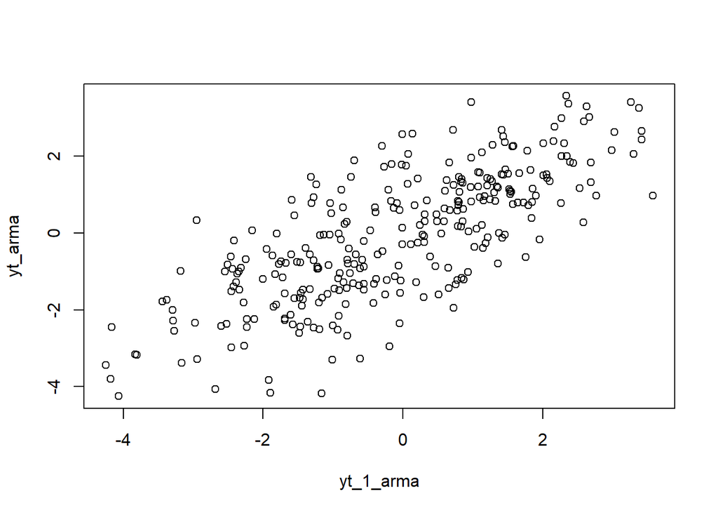

```r
plot(y=yt_arma,x=yt_1_arma)
```

Berdasarkan scatterplot tersebut, terlihat bahwa terdapat hubungan positif antara $Y_t$ dengan $Y_{t-1}$. Hal ini sesuai dengan teori yang ada

```r
cor(yt_arma,yt_1_arma)
```

```
## [1] 0.7500502
```

##### $Y_t$ dengan $Y_{t-2}$

```r
#Yt
yt_arma2 <- arma22[-c(1,2)]
yt_arma2
```

```
##   [1] -1.077217991 -1.591518838  0.857972776  0.621035121  1.370172149
##   [6] -0.007956387 -0.294459819 -0.468639788  0.064197964  1.280447276
##  [11]  2.299820151  2.331692495  3.570483281  0.975108360  1.955730067
##  [16] -0.166315069  1.795026529  0.716332295  2.684199639  1.838707447
##  [21]  0.386488842 -0.611271184 -3.272954173 -2.543542963 -1.000509445
##  [26] -2.414583612 -0.197220330 -2.951322140  0.338515524  0.850945663
##  [31]  1.301767007  1.052315350  0.109557613 -0.298376756  2.261822233
##  [36]  2.006523340  2.343710148  2.003844475  1.499738568  1.544194413
##  [41]  1.072603220  1.215097647 -0.118218819 -1.134909507 -0.046157902
##  [46] -2.350199766 -1.007307102 -3.293379577 -2.004973223 -1.197011866
##  [51] -2.508200886 -0.821371322 -1.848235549 -1.915646293 -3.826818975
##  [56] -3.166651363 -3.381488796 -1.745119860 -0.739691484  1.465071595
##  [61]  1.662114755  1.561746742  2.256486660  0.784682474  0.185865226
##  [66] -1.279230285  0.936579335  0.040043042  1.755268572 -0.627129785
##  [71] -1.359907284 -2.315126738 -0.904021314 -1.038691872  0.772934722
```

[output cut: 45 more lines]

```r
#Yt-2
yt_2_arma <- arma22[-c(299,300)]
yt_2_arma
```

```
##   [1] -0.423982089 -1.829945001 -1.077217991 -1.591518838  0.857972776
##   [6]  0.621035121  1.370172149 -0.007956387 -0.294459819 -0.468639788
##  [11]  0.064197964  1.280447276  2.299820151  2.331692495  3.570483281
##  [16]  0.975108360  1.955730067 -0.166315069  1.795026529  0.716332295
##  [21]  2.684199639  1.838707447  0.386488842 -0.611271184 -3.272954173
##  [26] -2.543542963 -1.000509445 -2.414583612 -0.197220330 -2.951322140
##  [31]  0.338515524  0.850945663  1.301767007  1.052315350  0.109557613
##  [36] -0.298376756  2.261822233  2.006523340  2.343710148  2.003844475
##  [41]  1.499738568  1.544194413  1.072603220  1.215097647 -0.118218819
##  [46] -1.134909507 -0.046157902 -2.350199766 -1.007307102 -3.293379577
##  [51] -2.004973223 -1.197011866 -2.508200886 -0.821371322 -1.848235549
##  [56] -1.915646293 -3.826818975 -3.166651363 -3.381488796 -1.745119860
##  [61] -0.739691484  1.465071595  1.662114755  1.561746742  2.256486660
##  [66]  0.784682474  0.185865226 -1.279230285  0.936579335  0.040043042
##  [71]  1.755268572 -0.627129785 -1.359907284 -2.315126738 -0.904021314
```

[output cut: 45 more lines]

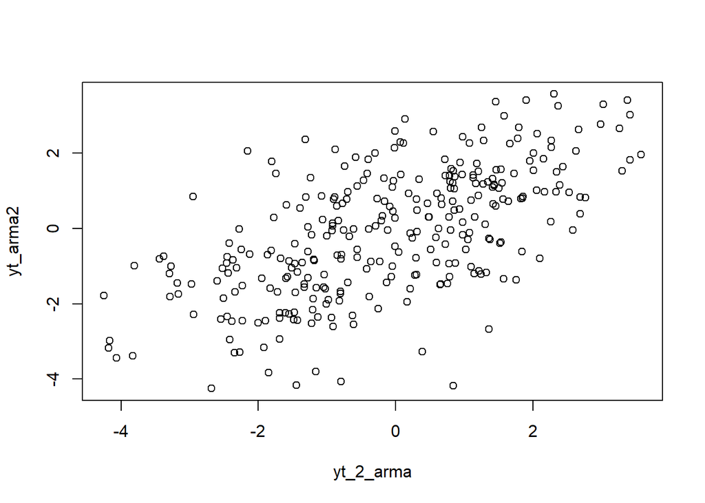

```r
plot(y=yt_arma2,x=yt_2_arma)
```

Berdasarkan scatterplot tersebut, terlihat bahwa terdapat hubungan positif antara $Y_t$ dengan $Y_{t-2}$. Hal ini sesuai dengan teori yang ada

```r
cor(yt_arma2,yt_2_arma)
```

```
## [1] 0.6199636
```

##### $Y_t$ dengan $Y_{t-3}$

```r
#Yt
yt_arma3 <- arma22[-c(1,2,3)]
yt_arma3
```

```
##   [1] -1.591518838  0.857972776  0.621035121  1.370172149 -0.007956387
##   [6] -0.294459819 -0.468639788  0.064197964  1.280447276  2.299820151
##  [11]  2.331692495  3.570483281  0.975108360  1.955730067 -0.166315069
##  [16]  1.795026529  0.716332295  2.684199639  1.838707447  0.386488842
##  [21] -0.611271184 -3.272954173 -2.543542963 -1.000509445 -2.414583612
##  [26] -0.197220330 -2.951322140  0.338515524  0.850945663  1.301767007
##  [31]  1.052315350  0.109557613 -0.298376756  2.261822233  2.006523340
##  [36]  2.343710148  2.003844475  1.499738568  1.544194413  1.072603220
##  [41]  1.215097647 -0.118218819 -1.134909507 -0.046157902 -2.350199766
##  [46] -1.007307102 -3.293379577 -2.004973223 -1.197011866 -2.508200886
##  [51] -0.821371322 -1.848235549 -1.915646293 -3.826818975 -3.166651363
##  [56] -3.381488796 -1.745119860 -0.739691484  1.465071595  1.662114755
##  [61]  1.561746742  2.256486660  0.784682474  0.185865226 -1.279230285
##  [66]  0.936579335  0.040043042  1.755268572 -0.627129785 -1.359907284
##  [71] -2.315126738 -0.904021314 -1.038691872  0.772934722 -1.223602887
```

[output cut: 45 more lines]

```r
#Yt-3
yt_3_arma <- arma22[-c(298,299,300)]
yt_3_arma
```

```
##   [1] -0.423982089 -1.829945001 -1.077217991 -1.591518838  0.857972776
##   [6]  0.621035121  1.370172149 -0.007956387 -0.294459819 -0.468639788
##  [11]  0.064197964  1.280447276  2.299820151  2.331692495  3.570483281
##  [16]  0.975108360  1.955730067 -0.166315069  1.795026529  0.716332295
##  [21]  2.684199639  1.838707447  0.386488842 -0.611271184 -3.272954173
##  [26] -2.543542963 -1.000509445 -2.414583612 -0.197220330 -2.951322140
##  [31]  0.338515524  0.850945663  1.301767007  1.052315350  0.109557613
##  [36] -0.298376756  2.261822233  2.006523340  2.343710148  2.003844475
##  [41]  1.499738568  1.544194413  1.072603220  1.215097647 -0.118218819
##  [46] -1.134909507 -0.046157902 -2.350199766 -1.007307102 -3.293379577
##  [51] -2.004973223 -1.197011866 -2.508200886 -0.821371322 -1.848235549
##  [56] -1.915646293 -3.826818975 -3.166651363 -3.381488796 -1.745119860
##  [61] -0.739691484  1.465071595  1.662114755  1.561746742  2.256486660
##  [66]  0.784682474  0.185865226 -1.279230285  0.936579335  0.040043042
##  [71]  1.755268572 -0.627129785 -1.359907284 -2.315126738 -0.904021314
```

[output cut: 45 more lines]

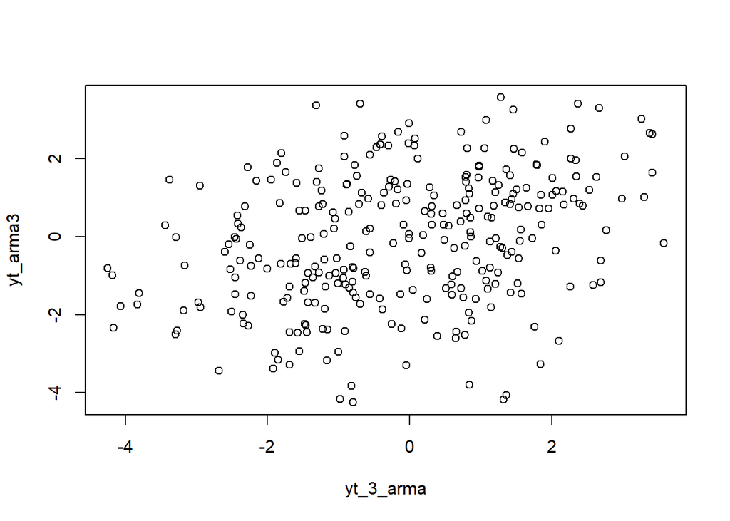

```r
plot(y=yt_arma3,x=yt_3_arma)
```

Berdasarkan scatterplot tersebut, terlihat bahwa terdapat hubungan positif antara $Y_t$ dengan $Y_{t-3}$. Hal ini sesuai dengan teori yang ada

```r
cor(yt_arma3,yt_3_arma)
```

```
## [1] 0.326507
```